# Lab #5: Drunk Driving & Fatal Accidents

Sydney Thompson

4/13/2021

# FARS Data

```r
acc <- read.csv("https://raw.githubusercontent.com/xdaiISU/ds202materials/master/hwlabs/fars2017/accident.csv", stringsAsFactors = FALSE)
```

```r
pers <- read.csv("https://raw.githubusercontent.com/xdaiISU/ds202materials/master/hwlabs/fars2017/person.csv", stringsAsFactors = FALSE)
```

```r
library(lubridate)
library(tidyverse)
```

```r
library(ggplot2)
```

# 1) Are there some days of the week where more accidents happen than the others (see FARS manual, use variable DAY_WEEK)?

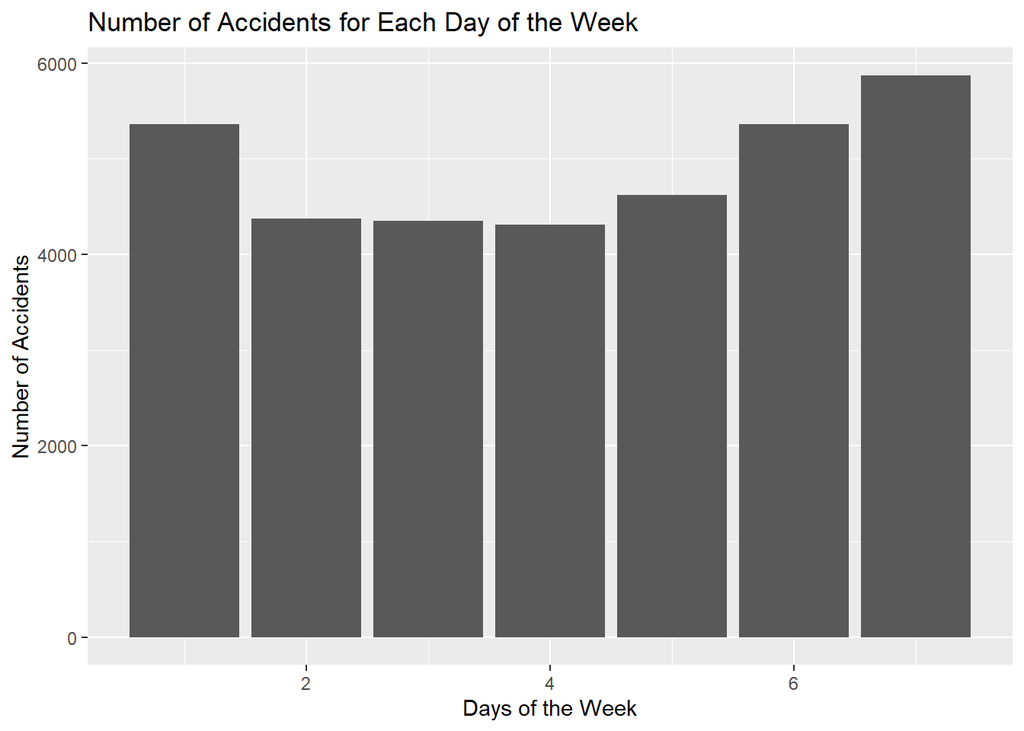

```r
ggplot(acc, aes(x=DAY_WEEK))+geom_bar()+xlab('Days of the Week')+ylab('Number of Accidents')+ggtitle('Number of Accidents for Each Day of the Week')
```

Yes. More accidents occur on the weekends, Friday, Saturday and Sunday. This is usually due to people not having work on the weekends which allows for people to drink and/or travel more on these days making accidents more prone.

# 2) Create a data frame containing the persons who are fatally hurt in the accidents (look up variable INJ_SEV)

```r
fatal_inj <- pers %>% group_by(INJ_SEV) %>% filter(INJ_SEV == 4)
fatal_inj
```

```
## # A tibble: 37,133 x 68
## # Groups:   INJ_SEV [1]
##    STATE ST_CASE VE_FORMS VEH_NO PER_NO STR_VEH COUNTY   DAY MONTH  HOUR MINUTE
##    <int>   <int>    <int>  <int>  <int>   <int>  <int> <int> <int> <int>  <int>
##  1     1   10001        1      1      1       0     73    19     2    23     35
##  2     1   10002        1      1      1       0     89    14     2    14     59
##  3     1   10003        3      2      1       0    101    31     1    20     31
##  4     1   10004        1      1      1       0     73     1     1    16     55
##  5     1   10005        1      1      1       0     13     1     1    20      0
##  6     1   10006        2      1      1       0     49     6     1    18     40
##  7     1   10007        2      1      1       0     73    11     1    17     57
##  8     1   10008        1      1      1       0      3    11     1    16     50
##  9     1   10009        1      1      1       0     87    11     1    14     30
## 10     1   10011        2      1      1       0     87    15     1     4     35
## # ... with 37,123 more rows, and 57 more variables: RUR_URB <int>,
## #   FUNC_SYS <int>, HARM_EV <int>, MAN_COLL <int>, SCH_BUS <int>, MAKE <int>,
## #   MAK_MOD <int>, BODY_TYP <int>, MOD_YEAR <int>, TOW_VEH <int>,
## #   SPEC_USE <int>, EMER_USE <int>, ROLLOVER <int>, IMPACT1 <int>,
## #   FIRE_EXP <int>, AGE <int>, SEX <int>, PER_TYP <int>, INJ_SEV <int>,
## #   SEAT_POS <int>, REST_USE <int>, REST_MIS <int>, AIR_BAG <int>,
## #   EJECTION <int>, EJ_PATH <int>, EXTRICAT <int>, DRINKING <int>,
## #   ALC_DET <int>, ALC_STATUS <int>, ATST_TYP <int>, ALC_RES <int>,
## #   DRUGS <int>, DRUG_DET <int>, DSTATUS <int>, DRUGTST1 <int>, DRUGTST2 <int>,
## #   DRUGTST3 <int>, DRUGRES1 <int>, DRUGRES2 <int>, DRUGRES3 <int>,
## #   HOSPITAL <int>, DOA <int>, DEATH_DA <int>, DEATH_MO <int>, DEATH_YR <int>,
## #   DEATH_HR <int>, DEATH_MN <int>, DEATH_TM <int>, LAG_HRS <int>,
## #   LAG_MINS <int>, P_SF1 <int>, P_SF2 <int>, P_SF3 <int>, WORK_INJ <int>,
## #   HISPANIC <int>, RACE <int>, LOCATION <int>
```

# 3) Create a data frame containing the most dangerous vehicle make in each state. The number of persons fatally hit in the vehicle make is used to assess the (non-)safety of a make. Make sure to handle the missing values appropriately. (look up variable MAKE)

```r
dang_vehicle <- fatal_inj %>% drop_na(MAKE)%>% group_by(STATE, MAKE) %>% summarize(count=n()) %>% group_by(STATE) %>% filter(count == max(count))
dang_vehicle
```

```
## # A tibble: 54 x 3
## # Groups:   STATE [51]
##    STATE  MAKE count
##    <int> <int> <int>
##  1     1    12   138
##  2     2    12     9
##  3     4    20    88
##  4     5    20    88
##  5     6    49   351
##  6     8    12    63
##  7     8    37    63
##  8     9    37    28
##  9    10    37    12
## 10    11    37     5
## # ... with 44 more rows
```

# 4) Create a map, and label each state with the most dangerous vehicle. Discuss the definition of the most dangerous vehicle, and what you find from the map. (Hint: Read the description for the STATE and COUNTY columns in the FARS manual. The state & county codes are Geographic Locator Codes (GLCs) from the General Services Administration’s (GSA) publication. Use readxl::read_xlsx to read in the GLCs.)

```r
states <- map_data('state')
str(states)
```

```
## 'data.frame':    15537 obs. of  6 variables:
##  $ long     : num  -87.5 -87.5 -87.5 -87.5 -87.6 ...
##  $ lat      : num  30.4 30.4 30.4 30.3 30.3 ...
##  $ group    : num  1 1 1 1 1 1 1 1 1 1 ...
##  $ order    : int  1 2 3 4 5 6 7 8 9 10 ...
##  $ region   : chr  "alabama" "alabama" "alabama" "alabama" ...
##  $ subregion: chr  NA NA NA NA ...
```

[figure not shown]

```r
acc_pers <- inner_join(acc, pers, by ="ST_CASE")
fatal_acc_pers <- acc_pers %>% filter(INJ_SEV == 4)
ggplot(fatal_acc_pers, aes(x=LONGITUD, y=LATITUDE, fill=MAKE)) + geom_polygon(aes(group=STATE.x))
```

# 5) Join the accident and person table (work out which variable(s) to use)

```r
acc_pers <- inner_join(acc, pers, by ="ST_CASE")
acc_pers
```

[output not shown]

[output cut: 12601 more lines]

# 6) Tally the number of accidents by day of the week (DAY_WEEK), hour of the day (HOUR) and gender (SEX). Visualize the results and explain what you find.

```r
acc_day <- acc %>% group_by(DAY_WEEK) %>% count(DAY_WEEK)
acc_day
```

```
## # A tibble: 7 x 2
## # Groups:   DAY_WEEK [7]
##   DAY_WEEK     n
##      <int> <int>
## 1        1  5360
## 2        2  4374
## 3        3  4347
## 4        4  4314
## 5        5  4621
## 6        6  5358
## 7        7  5873
```

For accidents by day of the week, one can see that days Friday(6), Saturday(7) and Sunday(1) have more accidents occur due to more travel on the weekends as people have free time off of work/school.

```r
acc_hour <- acc %>% group_by(HOUR) %>% count(HOUR)
acc_hour
```

```
## # A tibble: 25 x 2
## # Groups:   HOUR [25]
##     HOUR     n
##    <int> <int>
##  1     0  1321
##  2     1  1177
##  3     2  1241
##  4     3   957
##  5     4   813
##  6     5  1065
##  7     6  1282
##  8     7  1162
##  9     8   945
## 10     9   929
## # ... with 15 more rows
```

```r
acc_gender <- pers %>% group_by(SEX) %>% count(SEX)
acc_gender
```

```
## # A tibble: 4 x 2
## # Groups:   SEX [4]
##     SEX     n
##   <int> <int>
## 1     1 55230
## 2     2 28149
## 3     8   473
## 4     9  1069
```

For accidents based on gender, it appears that men(1) are in double the amount of accidents than women(2). This is surprising to me, but men seem to be more reckless at driving than women.

# 7) Now plot a choropleth map of the number of deaths on a county level. Also explain what you find.

[figure not shown]

```r
acc_pers_deaths <- acc_pers %>% filter(INJ_SEV == 4)
ggplot(acc_pers_deaths, aes(x = LONGITUD, y = LATITUDE, fill = INJ_SEV))+geom_polygon(aes(group=COUNTY.x))
```

# 8) Is summer or winter more dangerous? Does this depend on states? Explore and explain.

```r
summer <- acc %>% filter(MONTH >= 6 | MONTH <= 8) %>% select(STATE, FATALS) %>% group_by(STATE) %>% summarize(sumCount = sum(FATALS))
summer
```

```
## # A tibble: 51 x 2
##    STATE sumCount
##  * <int>    <int>
##  1     1      948
##  2     2       79
##  3     4     1000
##  4     5      493
##  5     6     3602
##  6     8      648
##  7     9      278
##  8    10      119
##  9    11       31
## 10    12     3112
## # ... with 41 more rows
```

```r
winter <- acc %>% filter(MONTH >= 11 | MONTH <= 2) %>% select(STATE, FATALS) %>% group_by(STATE) %>% summarize(winCount = sum(FATALS))
winter
```

```
## # A tibble: 51 x 2
##    STATE winCount
##  * <int>    <int>
##  1     1      286
##  2     2       28
##  3     4      323
##  4     5      147
##  5     6     1171
##  6     8      180
##  7     9       89
##  8    10       39
##  9    11       10
## 10    12     1090
## # ... with 41 more rows
```

```r
total_summer_fatal <- sum(summer$sumCount)
total_summer_fatal
```

```
## [1] 37133
```

```r
total_winter_fatal <- sum(winter$winCount)
total_winter_fatal
```

```
## [1] 11496
```